# Final Resource

## Introduction

As the sports industry continues to grow over time, the integration of advanced analytics via statistics and machine learning plays a vital role in how professional sporting teams operate and play. Is it possible to predict outcomes of sporting events given historical data, and if so, how accurately?

This report will answer the research question: *can historical data on NCAA basketball results be used to predict outcomes of future matches?* We will be using the dataset from the [Google Cloud & NCAA® ML Competition 2018-Men'](https://www.kaggle.com/c/mens-machine-learning-competition-2018) competition to build and test machine learning models. To predict the outcome of a given basketball game, our team is interested in comparing a team's recent performance (based on the last 8 games of the season) and current Elo score (a team's "rating"), against other team's recent performance and Elo score.

Our hypothesis is: *Does utilizing ELO ranking given historical accompanied by a team’s recent performance allow for us to predict if team A will beat team B in a game of basketball?* Specifically, our end result will be the probability that team A beats team B for each matchup in the 2017 March Madness tournament. We will test this by measuring the accuracy of our model to predict the outcomes of the 2017 March Madness tournament since the seeds for 2018 have not been released. We will then use the accuracy of our results in our final evaluation.

Please refer to our [repo](https://github.com/ssharif6/info370-FinalProject) for all the code for this project.

## Dataset Overview

This dataset includes historical data from both the regular season and NCAA championship tournaments. We will only use up to 2017 regular season data, but not train the model with 2017 tournament data, as this would skew our results. Our exploratory data analysis will include the whole data set to show the breadth of the data.

## Statistical and Machine Learning Methods

For stat-analysis, we utilized statistical analysis to perform EDA, and utilize logistic regression models to predict trends/analyze our research question. We will also utilize ELO-Ranking as our metric for determining probabilities of winning basketball games, which will be aggregated over seasons from 1985 - 2017.

For machine learning, we plan to use either logistic regression, xgboost, or another boosting algorithm for machine learning, paired with proper cross-validation / GridSearchCV.

## Data Overview

To get started, here is a brief data overview of the teams, seasons, seeds, regular season compact results, and tourney and regular season detailed results. This will help you get familiarize with the dataset.

### Teams

There are 351 college teams currently in Division-I, and an overall total of 364 teams in the dataset. Each team has a 4 digit id number.

> **TeamID** - a 4 digit id number, from 1000-1999, uniquely identifying each NCAA® men's team.

> **TeamName** - a compact spelling of the team's college name, 16 characters or fewer. There are no commas or double-quotes in the team names, but you will see some characters that are not letters or spaces (e.g., Texas A&M, St Mary's CA, etc.)

> **FirstD1Season** - the first season in our dataset that the school was a Division-I school. Many schools were Division-I far earlier than 1985, but since we don not have any data included prior to 1985, all such teams are listed with a FirstD1Season of 1985.

> **LastD1Season** - the last season in our dataset that the school was a Division-I school. For any teams that are currently Division-I, they will be listed with LastD1Season=2018, and you can confirm there are 351 such teams.

|  | TeamID | TeamName | FirstD1Season | LastD1Season |
| --- | --- | --- | --- | --- |
| 0 | 1101 | Abilene Chr | 2014 | 2018 |
| 1 | 1102 | Air Force | 1985 | 2018 |
| 2 | 1103 | Akron | 1985 | 2018 |
| 3 | 1104 | Alabama | 1985 | 2018 |
| 4 | 1105 | Alabama A&M | 2000 | 2018 |

### Seasons

This dataset identifies the different seasons included in the historical data, along with certain season-level properties.

> **Season** - indicates the year in which the tournament was played

> **DayZero** - tells you the date corresponding to daynum=0 during that season. All game dates have been aligned upon a common scale so that the championship game of the final tournament is on daynum=154. Working backward, the national semifinals are always on daynum=152, the "play-in" games are on days 134/135, Selection Sunday is on day 132, and so on. All game data includes the day number in order to make it easier to perform date calculations. If you really want to know the exact date a game was played on, you can combine the game's "daynum" with the season's "dayzero".

> **RegionW, RegionX, Region Y, Region Z** - by convention, the four regions in the final tournament are always named W, X, Y, and Z. Whichever region's name comes first alphabetically, that region will be Region W. And whichever Region plays against Region W in the national semifinals, that will be Region X. For the other two regions, whichever region's name comes first alphabetically, that region will be Region Y, and the other will be Region Z. This allows us to identify the regions and brackets in a standardized way in other files. So for that season, the W/X/Y/Z are East,Midwest,South,West.

|  | Season | DayZero | RegionW | RegionX | RegionY | RegionZ |
| --- | --- | --- | --- | --- | --- | --- |
| 0 | 1985 | 10/29/1984 | East | West | Midwest | Southeast |
| 1 | 1986 | 10/28/1985 | East | Midwest | Southeast | West |
| 2 | 1987 | 10/27/1986 | East | Southeast | Midwest | West |
| 3 | 1988 | 11/2/1987 | East | Midwest | Southeast | West |
| 4 | 1989 | 10/31/1988 | East | West | Midwest | Southeast |

### NCAA Tourney Seed

> **Season** - the year that the tournament was played in

> **Seed** - this is a 3/4-character identifier of the seed, where the first character is either W, X, Y, or Z (identifying the region the team was in) and the next two digits (either 01, 02, ..., 15, or 16) tells you the seed within the region. For play-in teams, there is a fourth character (a or b) to further distinguish the seeds, since teams that face each other in the play-in games will have seeds with the same first three characters. For example, the first record in the file is seed W01, which means we are looking at the #1 seed in the W region (which we can see from the "Seasons.csv" file was the East region).

> **TeamID** - this identifies the id number of the team, as specified in the Teams.csv file

|  | Season | Seed | TeamID |
| --- | --- | --- | --- |
| 0 | 1985 | W01 | 1207 |
| 1 | 1985 | W02 | 1210 |
| 2 | 1985 | W03 | 1228 |
| 3 | 1985 | W04 | 1260 |
| 4 | 1985 | W05 | 1374 |

### Regular Season Compact Results

This datset identifies the game-by-game results for many seasons of historical data, starting with the 1985 season (the first year the NCAA® had a 64-team tournament). For each season, the file includes all games played from daynum 0 through 132. It is important to realize that the "Regular Season" games are simply defined to be all games played on DayNum=132 or earlier (DayNum=132 is Selection Sunday, and there are always a few conference tournament finals actually played early in the day on Selection Sunday itself). Thus a game played on or before Selection Sunday will show up here whether it was a pre-season tournament, a non-conference game, a regular conference game, a conference tournament game, etc.

> **Season** - this is the year of the associated entry in Seasons.csv (the year in which the final tournament occurs)

> **DayNum** - this integer always ranges from 0 to 132, and tells you what day the game was played on. It represents an offset from the "DayZero" date in the "Seasons.csv" file.

> **WTeamID** - this identifies the id number of the team that won the game, as listed in the "Teams.csv" file. No matter whether the game was won by the home team or visiting team, or if it was a neutral-site game, the "WTeamID" always identifies the winning team.

> **WScore** - this identifies the number of points scored by the winning team.

> **LTeamID** - this identifies the id number of the team that lost the game.

> **LScore** - this identifies the number of points scored by the losing team. Thus you can be confident that WScore will be greater than LScore for all games listed.

> **NumOT** - this indicates the number of overtime periods in the game, an integer 0 or higher.

> **WLoc** - this identifies the "location" of the winning team. If the winning team was the home team, this value will be "H". If the winning team was the visiting team, this value will be "A". If it was played on a neutral court, then this value will be "N".

|  | Season | DayNum | WTeamID | WScore | LTeamID | LScore | WLoc | NumOT |
| --- | --- | --- | --- | --- | --- | --- | --- | --- |
| 0 | 1985 | 20 | 1228 | 81 | 1328 | 64 | N | 0 |
| 1 | 1985 | 25 | 1106 | 77 | 1354 | 70 | H | 0 |
| 2 | 1985 | 25 | 1112 | 63 | 1223 | 56 | H | 0 |
| 3 | 1985 | 25 | 1165 | 70 | 1432 | 54 | H | 0 |
| 4 | 1985 | 25 | 1192 | 86 | 1447 | 74 | H | 0 |

### NCAA Tourney Detailed Results

This file provides team-level box scores for many NCAA® tournaments, starting with the 2003 season. All games listed in the NCAATourneyCompactResults file since the 2003 season should exactly be present in the NCAATourneyDetailedResults file. The **W** represents for winning team, and the **L** represents the losing team.

> **FGM** — Field Goals Made

> **FGA** — Field Goals Attempted

> **FGM3** — Three Pointers Made

> **FGA3** — Three Pointers Attempted

> **FTM** — Free Throws Made

> **FTA** — Free Throws Attempted

> **OR** — Offensive Rebounds

> **DR** — Defensive Rebounds

> **AST** — Assists

> **TO** — Turnovers

> **STL** — Steals

> **BLK** — Bocks

> **PF** — Personal Fouls

|  | Season | DayNum | WTeamID | WScore | LTeamID | LScore | WLoc | NumOT | WFGM | WFGA | ... | LFGA3 | LFTM | LFTA | LOR | LDR | LAst | LTO | LStl | LBlk | LPF |
| --- | --- | --- | --- | --- | --- | --- | --- | --- | --- | --- | --- | --- | --- | --- | --- | --- | --- | --- | --- | --- | --- |
| 0 | 2003 | 134 | 1421 | 92 | 1411 | 84 | N | 1 | 32 | 69 | ... | 31 | 14 | 31 | 17 | 28 | 16 | 15 | 5 | 0 | 22 |
| 1 | 2003 | 136 | 1112 | 80 | 1436 | 51 | N | 0 | 31 | 66 | ... | 16 | 7 | 7 | 8 | 26 | 12 | 17 | 10 | 3 | 15 |
| 2 | 2003 | 136 | 1113 | 84 | 1272 | 71 | N | 0 | 31 | 59 | ... | 28 | 14 | 21 | 20 | 22 | 11 | 12 | 2 | 5 | 18 |
| 3 | 2003 | 136 | 1141 | 79 | 1166 | 73 | N | 0 | 29 | 53 | ... | 17 | 12 | 17 | 14 | 17 | 20 | 21 | 6 | 6 | 21 |
| 4 | 2003 | 136 | 1143 | 76 | 1301 | 74 | N | 1 | 27 | 64 | ... | 21 | 15 | 20 | 10 | 26 | 16 | 14 | 5 | 8 | 19 |

5 rows × 34 columns

### Regular Season Detailed Results

This file provides team-level box scores for many regular seasons of historical data, starting with the 2003 season. All games listed in the RegularSeasonCompactResults file since the 2003 season should exactly be present in the RegularSeasonDetailedResults file.

> **FGM** — Field Goals Made

> **FGA** — Field Goals Attempted

> **FGM3** — Three Pointers Made

> **FGA3** — Three Pointers Attempted

> **FTM** — Free Throws Made

> **FTA** — Free Throws Attempted

> **OR** — Offensive Rebounds

> **DR** — Defensive Rebounds

> **AST** — Assists

> **TO** — Turnovers

> **STL** — Steals

> **BLK** — Bocks

> **PF** — Personal Fouls

|  | Season | DayNum | WTeamID | WScore | LTeamID | LScore | WLoc | NumOT | WFGM | WFGA | ... | LFGA3 | LFTM | LFTA | LOR | LDR | LAst | LTO | LStl | LBlk | LPF |
| --- | --- | --- | --- | --- | --- | --- | --- | --- | --- | --- | --- | --- | --- | --- | --- | --- | --- | --- | --- | --- | --- |
| 0 | 2003 | 10 | 1104 | 68 | 1328 | 62 | N | 0 | 27 | 58 | ... | 10 | 16 | 22 | 10 | 22 | 8 | 18 | 9 | 2 | 20 |
| 1 | 2003 | 10 | 1272 | 70 | 1393 | 63 | N | 0 | 26 | 62 | ... | 24 | 9 | 20 | 20 | 25 | 7 | 12 | 8 | 6 | 16 |
| 2 | 2003 | 11 | 1266 | 73 | 1437 | 61 | N | 0 | 24 | 58 | ... | 26 | 14 | 23 | 31 | 22 | 9 | 12 | 2 | 5 | 23 |
| 3 | 2003 | 11 | 1296 | 56 | 1457 | 50 | N | 0 | 18 | 38 | ... | 22 | 8 | 15 | 17 | 20 | 9 | 19 | 4 | 3 | 23 |
| 4 | 2003 | 11 | 1400 | 77 | 1208 | 71 | N | 0 | 30 | 61 | ... | 16 | 17 | 27 | 21 | 15 | 12 | 10 | 7 | 1 | 14 |

5 rows × 34 columns

## Exploratory Data Analysis

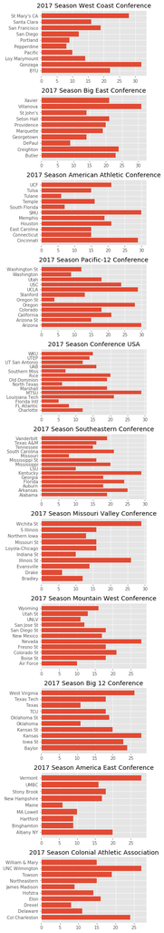

> Here, the graphs above reveal the total number of wins per team for each conference in 2017 (ex. for the West Coast Conference, Gonzaga had the most amount of wins, whereas Pepperdine had the least). This gives us a good overview of the teams that had the most amount of wins compared to the other teams in the same each area. Then we can use this to compare their wins against the other conferences.

```
<function matplotlib.pyplot.show>
```

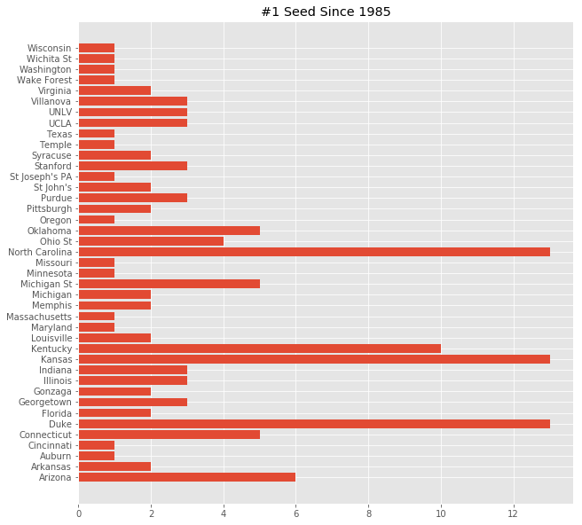

> The graph above shows the number of times each team has been the number 1 seed since 1985. Out of all the colleges, North Carolina, Kansas, and Duke have gotten the number 1 seed the most amount of times compared to the other teams. From here we can see that these three teams have consistently (and drastically) been the number 1 seed in comparison to other college teams.

```
<function matplotlib.pyplot.show>
```

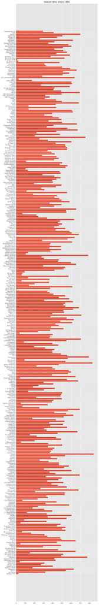

> This graph provides an overview of the season wins for each team since 1985. Similar to the previous graph, the North Carolina, Kansas, and Duke teams have been performing well since 1985, with the most amount of season wins along with Kentucky and Arizona.

## Data Analysis

|  | TeamID | ELO | TeamName |
| --- | --- | --- | --- |
| 0 | 1291 | 1499 | Mt St Mary's |
| 1 | 1292 | 1897 | MTSU |
| 2 | 1297 | 1643 | N Kentucky |
| 3 | 1300 | 1477 | NC Central |
| 4 | 1305 | 1914 | Nevada |
| 5 | 1308 | 1775 | New Mexico St |
| 6 | 1309 | 1472 | New Orleans |
| 7 | 1314 | 2142 | North Carolina |
| 8 | 1315 | 1583 | North Dakota |
| 9 | 1321 | 1936 | Northwestern |
| 10 | 1323 | 2085 | Notre Dame |
| 11 | 1329 | 1947 | Oklahoma St |
| 12 | 1332 | 2140 | Oregon |
| 13 | 1343 | 1822 | Princeton |
| 14 | 1344 | 1993 | Providence |
| 15 | 1345 | 2086 | Purdue |
| 16 | 1348 | 1926 | Rhode Island |
| 17 | 1355 | 1686 | S Dakota St |
| 18 | 1112 | 2161 | Arizona |
| 19 | 1371 | 2036 | Seton Hall |
| 20 | 1116 | 1980 | Arkansas |
| 21 | 1374 | 2109 | SMU |
| 22 | 1376 | 1920 | South Carolina |
| 23 | 1124 | 2069 | Baylor |
| 24 | 1388 | 2010 | St Mary's CA |
| 25 | 1137 | 1684 | Bucknell |
| 26 | 1139 | 2046 | Butler |
| 27 | 1407 | 1562 | Troy |
| 28 | 1153 | 2042 | Cincinnati |
| 29 | 1411 | 1532 | TX Southern |
| ... | ... | ... | ... |
| 38 | 1436 | 1785 | Vermont |
| 39 | 1437 | 2216 | Villanova |
| 40 | 1438 | 2082 | Virginia |
| 41 | 1181 | 2134 | Duke |
| 42 | 1439 | 1966 | Virginia Tech |
| 43 | 1190 | 1719 | ETSU |
| 44 | 1448 | 1882 | Wake Forest |
| 45 | 1195 | 1672 | FL Gulf Coast |
| 46 | 1196 | 2017 | Florida |
| 47 | 1452 | 2094 | West Virginia |
| 48 | 1199 | 2024 | Florida St |
| 49 | 1455 | 2056 | Wichita St |
| 50 | 1457 | 1658 | Winthrop |
| 51 | 1458 | 2043 | Wisconsin |
| 52 | 1462 | 1990 | Xavier |
| 53 | 1211 | 2134 | Gonzaga |
| 54 | 1233 | 1698 | Iona |
| 55 | 1235 | 2084 | Iowa St |
| 56 | 1240 | 1489 | Jacksonville St |
| 57 | 1242 | 2199 | Kansas |
| 58 | 1243 | 1926 | Kansas St |
| 59 | 1245 | 1721 | Kent |
| 60 | 1246 | 2156 | Kentucky |
| 61 | 1257 | 2095 | Louisville |
| 62 | 1266 | 1945 | Marquette |
| 63 | 1268 | 2015 | Maryland |
| 64 | 1274 | 2036 | Miami FL |
| 65 | 1276 | 2040 | Michigan |
| 66 | 1277 | 1998 | Michigan St |
| 67 | 1278 | 1931 | Minnesota |

68 rows × 3 columns

```
<function matplotlib.pyplot.show>
```

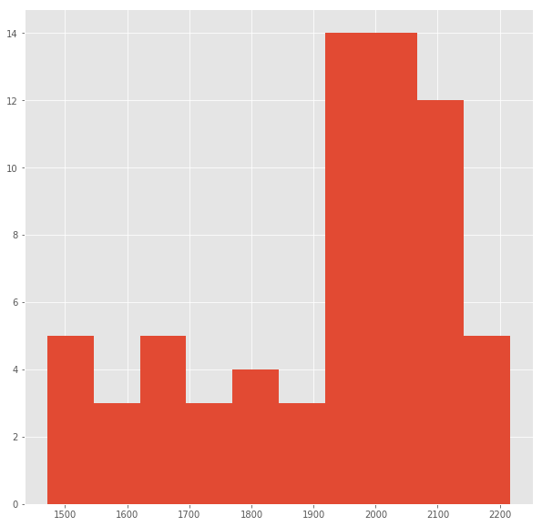

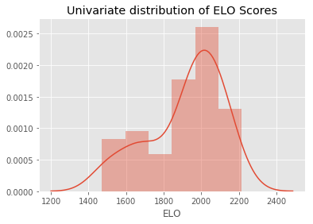

> From the univariate distribution above, we get a sense for how the ELO scores are distributed. From the curve, we can see that the distribution appears bimodal (two modes). The main peak is in between an ELO score of 2000 and 2200, whereas the second and lower peak is at 1600.

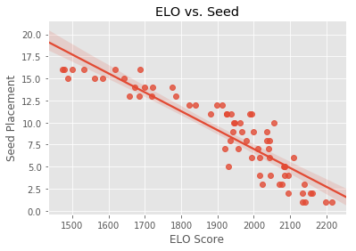

> In this scatter plot, we can see a negative trend from the best fit line in the ELO score and seed placement. Thus, the lower the ELO score the higher the seed placement and vice versa (the higher the ELO score the lower the seed placement).

## Random Pick Simulations

```
count    10000.000000
mean       311.953000
std        133.251009
min         50.000000
25%        230.000000
50%        280.000000
75%        360.000000
max       1170.000000
dtype: float64
```

# Statistical & ML Methods

## Data Prep

In general, we utilized the game stats provided by us to the DetailedSeasonData, as well as DetailedNCAATourney data. We extracted the following list of features to incorporate into our feature vector:

- Score: Score of the game
- fga: Field Goals Attempted
- fgp: Field Goal Percentage
- fga3: 3Pt Field Goal Attempts
- 3pp: 3Pt percentage
- ftp: Free Throw Percentage
- or: Offensive Rebounds
- dr: Deffensive Rebounds
- ast: Num Assists
- to: Turnovers
- stl: Steals
- blk: Blocks
- pf: Personal Fouls

Using the stats above, we aggregated data over seasons from 1985 - 2017 to generate an **ELO Score** (https://fivethirtyeight.com/features/how-we-calculate-nba-elo-ratings/). ELO scoring allowed us to create a provisional ranking that weighs into our model's prediction whether or not team A bill beat team B.

One of the ways in which we formatted our data was having one row represent the stats for the *Winning Team* **and** the *Losing Team*. We then appended lists with the above data fields for the *Winning Team* followed by the *Losing Team* features, as well as the corresponding ELO scores.

One feacture vector thus had the following format:

### **`< WinningElo, 85, 32, 67, ..., LosingTeamELO, 65, 44, ... >`**

Our **Y** was a simple 1 or 0, where 0 represents the first team winning, and 1 represents the second team winning.

The second way in which we formatted our data was having our feature vector contain the **differences** between the winning team's features and the losing team's features. This would allow for the model to make associations between various features and highlight key differences that could be used to predict other games. For instance, if **winning teams** tend to always have a higher *rebound* difference, the model could learn to weigh rebound count more heavily than for instance personal fouls.

### **`< WinningElo-LosingELO, 20, 23, ... >`**

Our **Y** was also a simple 1 or 0, where 0 represents the first team winning, and 1 represents the second team winning.

Another direction we experimented with was with changing the output of Y. Following a similar model from our second data prep method, we tried having Y represent the differential between the winning team score and the losing team score. This would allow for the model to not weigh teams that blow out other teams by 40 points have the same weight as a team that won a game by 1 point in triple overtime.

After going through all the regular season games and tourney games, our final training data to send the model was a collection of feature vectors. We then proceeded to let our model fit on our featureset.

## Metrics

For modeling, we trained seperate models using **neg_log_loss** and **accuracy**. The outputs of those models are shown below. We then used the models to simulate basketball games in accordance to the March Maddness tournament bracket to find our final metric, which was **Bracket Score**.

We followed ESPN's bracket scoring system, which means that if you accurately predict the **winner** of a first round game, you get 10 points, 20 points for second round, 40 pounds for third, 80 for fourth, 160 for fifth, 320 for final.

We utilized **bracket score** as our underlying metric, specifically using ESPN's bracket scoring system (https://www.printyourbrackets.com/bracket-scoring.html). We chose this as our metric over general accuracy of a basketball game, as it allowed our models to learn to maximize winning brackets

## Modeling

Initially, we created and optimized a pipeline that aimed to minimize **log loss**, in accordance to the scoring metric used by Kaggle's March Maddness Competition. This led us to our first model pipeline, which used *scaling* to make data more robust to outliers (*RobustScaler*), *Stacking Estimator*) to combine classifiers, and a combination of *Gradient Boost* (XGBClassifier), *Naive Bayes* (GaussianNB), *Support Vector Machines* (LinearSVC), and *Logistic Regression*.

We chose to use **Gaussian Naive Bayes** due to the nature of our data being *continuous*, and our assumption that each of our columns should follow a *normal distribution*. We also used SVM’s for the application in being to applying features in higher-dimension feature spaces.

For the second model, we realized that it doesn’t matter how much an individual team loses by, and how close it is to the correct value, which is what log loss aims to minimize. Rather, we only care about whether or not we can predict a matchup’s outcome correctly. This led to our second model, *which used the same input as the first model*, but was optimized on **maximizing ‘accuracy**. Our second pipeline used **Independent Component Analysis (FastICA)** because of the possibility of mixed signals/noise within our data, and Naive Bayes (Gaussian NB).

The problem with the previous two pipelines is that they aim to predict matches correctly, but this may not be the same as our goal, which is to maximize score in NCAA bracket. Thus, we wanted to create a new model that would **optimize bracket scores**. This involved creating a new scoring function, and even a new classifier (which we did in Torch). This new classifier takes in training data, and then creates a pipeline for predictions. We then take these predictions and run a simulation, and return the outputted score as the ‘score’ to the classifier. After receiving the score, the classifier then tweaks the pipeline hyperparameters and repeats the process.

## Random Simulations

In order to set a baseline, we decided to run a simulation of NCAA's March Maddnes tournament bracket for the year of 2017 where we randomly filled out brackets and checked the overall bracket score. Although we ran our random simulations on the 2017 bracket, the year has no impact on the results.

## Random Simulation Results

```
count    10000.000000
mean       311.953000
std        133.251009
min         50.000000
25%        230.000000
50%        280.000000
75%        360.000000
max       1170.000000
```

[figure not shown]

```python
# Random
mu = 311.953000
variance = 1
sigma = math.sqrt(variance)
x = np.linspace(mu-3*sigma,mu+3*sigma,100)
plt.plot(x, mlab.normpdf(x, mu, sigma))

plt.xlabel('Score')
plt.ylabel('Proportion')
plt.title('Random Score Distribution')
plt.show()
```

### First Model (Neg Log Loss)

The results for our initial model using **neg log loss** as our scoring metric (*code for calculations in modeling.ipynb*):

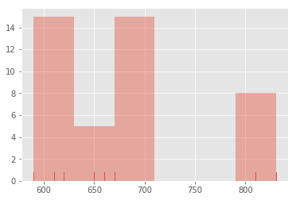

## Model 1 Results

```
count     43.000000
mean     670.930233
std       82.658620
min      590.000000
25%      590.000000
50%      670.000000
75%      670.000000
max      830.000000
dtype: float64
```

## Second Model (Accuracy)

The results for our second model using **accuracy** as our scoring metric (*code for calculations in modeling.ipynb*)

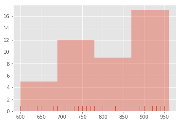

## Model 2 Results

```
count     43.000000
mean     812.325581
std      106.923141
min      600.000000
25%      745.000000
50%      790.000000
75%      925.000000
max      960.000000
dtype: float64
```

Mean Bracket Score: 812.32558139534888

# Conclusion

[output not shown]

\begin{eqnarray} \frac{\sigma}{\sqrt{N}}\\ \end{eqnarray}

[output not shown]

[output not shown]